# SCEPTRE Resampling Distributions

2022-07-21

The goal of this document is to explore the resampling distribution of SCEPTRE on the Gasperini data, and assess the extent to which the skew-t or normal distributions fit to this data. Since the discreteness in the resampling distribution is a reflection of the discreteness in the gene and gRNA data, i.e. the number of cells they are expressed in. We choose a set of genes and gRNAs across this spectrum (25 each), and run SCEPTRE on the Cartesian product set of 625 pairs. Here is a subset of the resampling distributions, with skew-t and normal distributions overlaid.

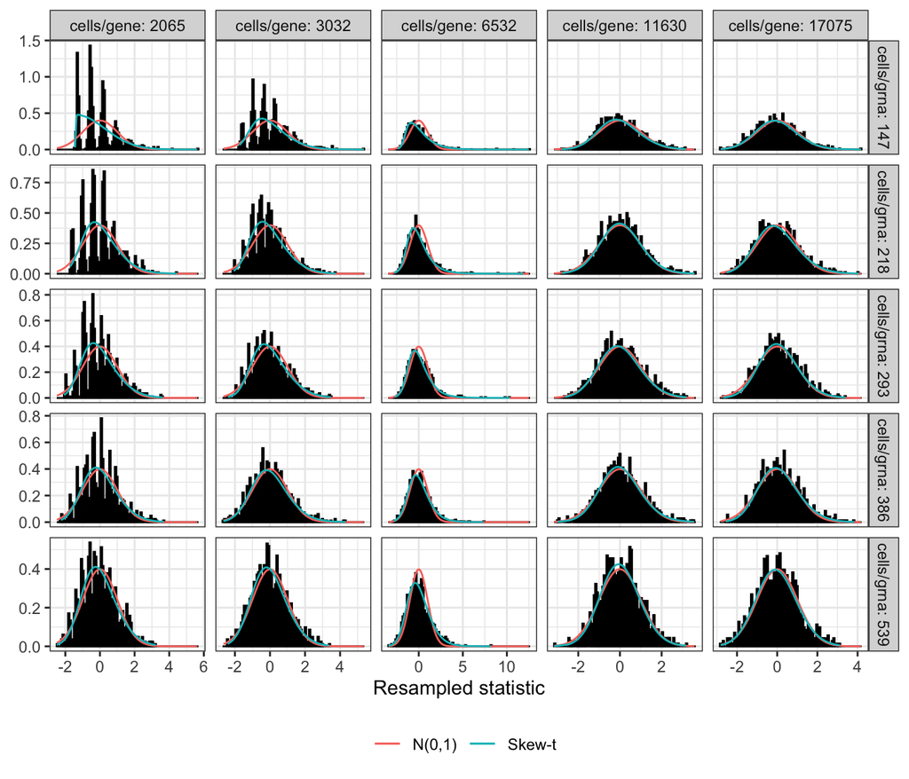

We see that the spiky behavior improves as the number of cells per gene or per gRNA increases. To formalize whether a distribution fits the resampled statistics well, we can use one-sample KS tests. We try three options (ordered from most flexible to least flexible): skew-t, normal with fitted mean and variance, and standard normal.

Let’s define a bad fit as a pair for which the KS p-value is below 0.05. We plot the fit quality for each of the three distributions as a function of cells/gene and cells/gRNA.

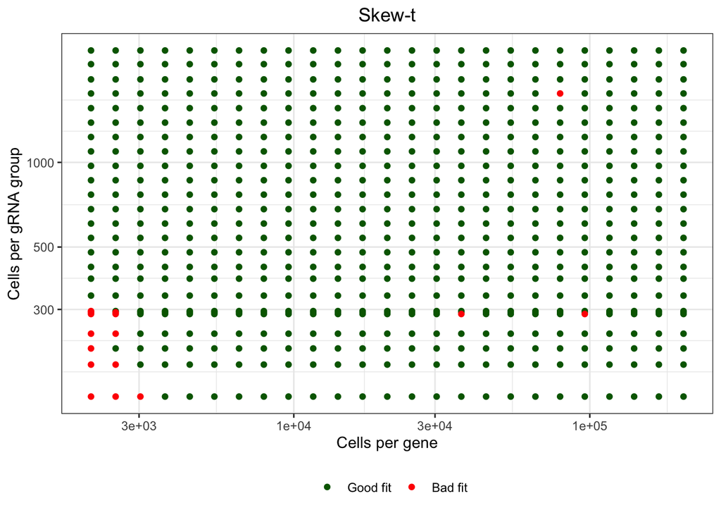

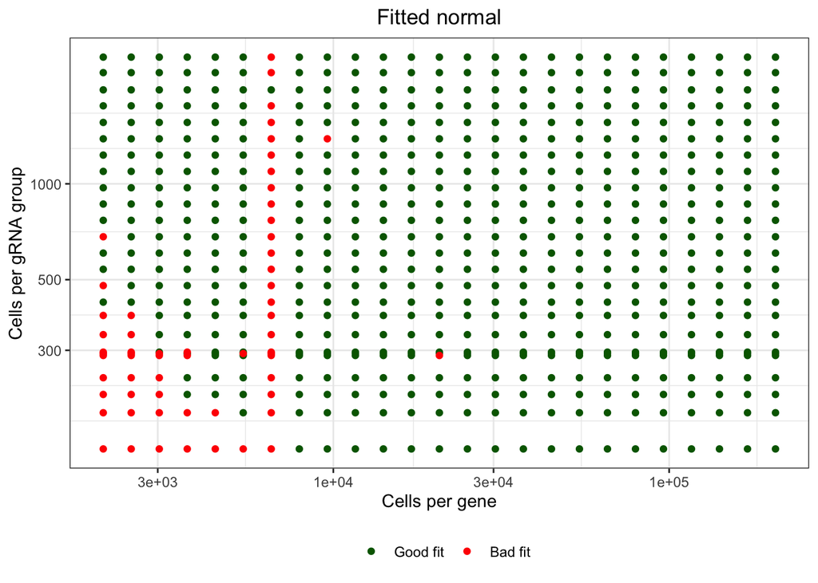

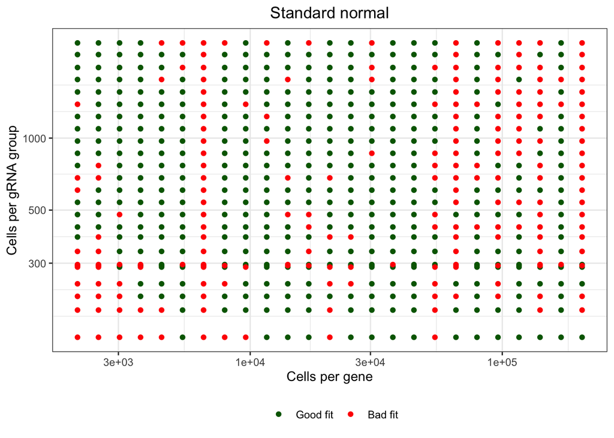

We see that the skew-t fit is usually good for pairs with at least 300 cells per gRNA group or at least 3000 cells per gene. The latter cutoff is about 1.5% of all cells. Let’s put these cutoffs in the context of the Gasperini data.

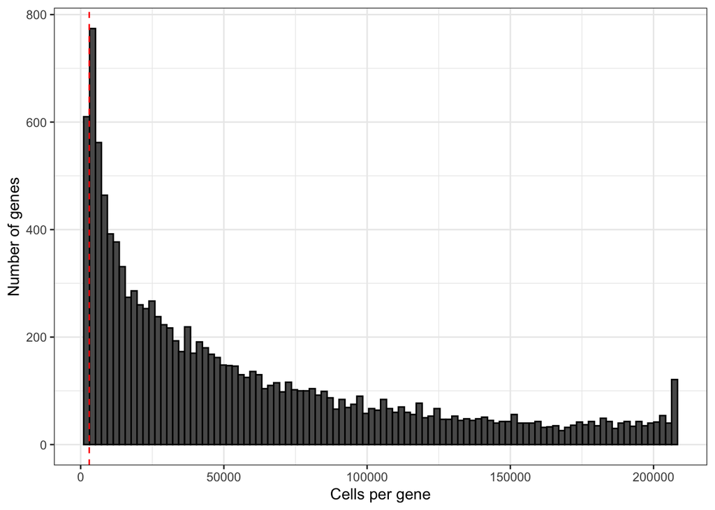

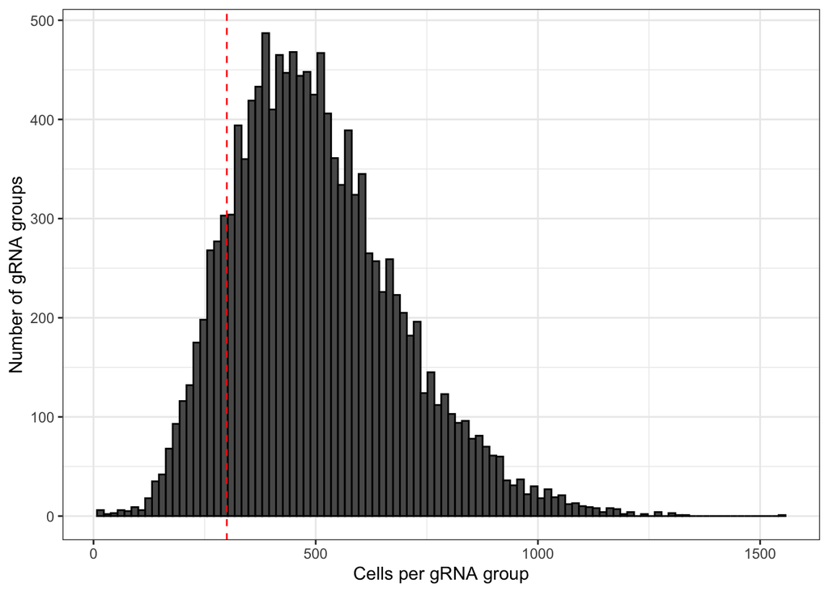

About 95% of the Gasperini genes are expressed in at least 3000 cells, and about 87% of gRNA groups are expressed in at least 300 cells. Among the roughly 80,000, Gasperini cis pairs, only one involves a gene expressed in at most 3000 cells and a gRNA group expressed in at most 300 cells.